# Roberts TS Final Data Preprocessing and Exploration

Madeleine Roberts

2024-05-20

## Results:

1. From plotting the data, we see that we should likely log our data to account for different levels of variance at different time periods.
2. From the ACF and PCF plots, we see that it is extremely important that our models account for seasonality.
3. From the Dickey-Fuller and KPSS tests, we see that it that our models should account for differencing in order to make it stationary.
4. We will use tsoutliers to detect and impute outliers at each junction.
5. We see that for all junctions there is a heavy skew to the right.

## Data Setup

```r
traffic <- read.csv("traffic.csv")

# Separate into different junctions
traffic_j1 <- traffic %>%
  filter(Junction == 1)

traffic_j2 <- traffic %>%
  filter(Junction == 2)

traffic_j3 <- traffic %>%
  filter(Junction == 3)

traffic_j4 <- traffic %>%
  filter(Junction == 4)

# Change time column into a frequency
traffic_j1 <- traffic_j1 %>%
  mutate(Time = row_number())

traffic_j2 <- traffic_j2 %>%
  mutate(Time = row_number())

traffic_j3 <- traffic_j3 %>%
  mutate(Time = row_number())

traffic_j4 <- traffic_j4 %>%
  mutate(Time = row_number())

# Convert dataframe to a time series
traffic_ts_j1 <- as_tsibble(traffic_j1, index = Time)
traffic_ts_j2 <- as_tsibble(traffic_j2, index = Time)
traffic_ts_j3 <- as_tsibble(traffic_j3, index = Time)
traffic_ts_j4 <- as_tsibble(traffic_j4, index = Time)
```

## Junction 1

**Plot data:**

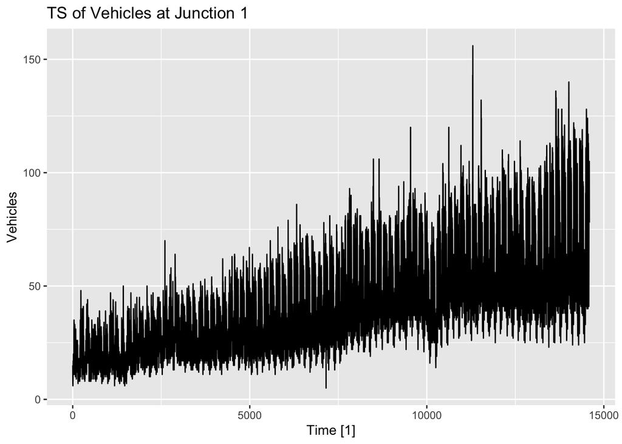

```r
traffic_ts_j1 %>%
  autoplot(Vehicles) +
  labs(title = "TS of Vehicles at Junction 1")
```

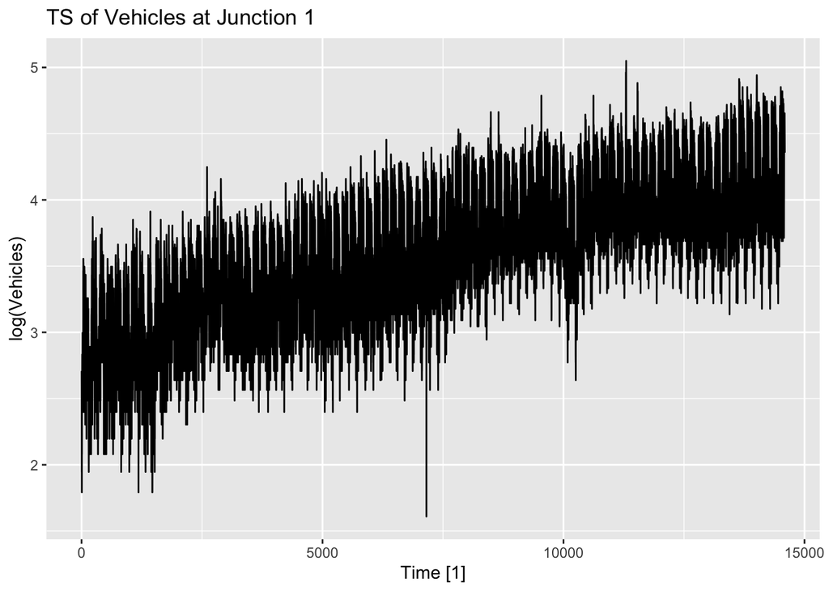

```r
traffic_ts_j1 %>%
  autoplot(log(Vehicles)) +
  labs(title = "TS of Vehicles at Junction 1")
```

Logging the data helps with the heteroskdasticity

**Looking at Autocorrelation Function**

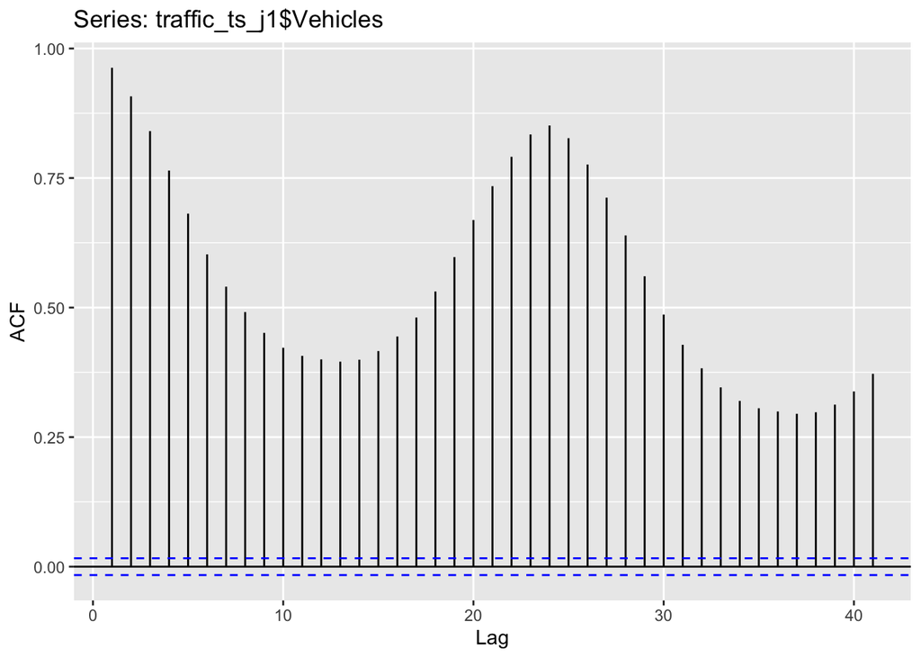

```r
ggAcf(traffic_ts_j1$Vehicles)
```

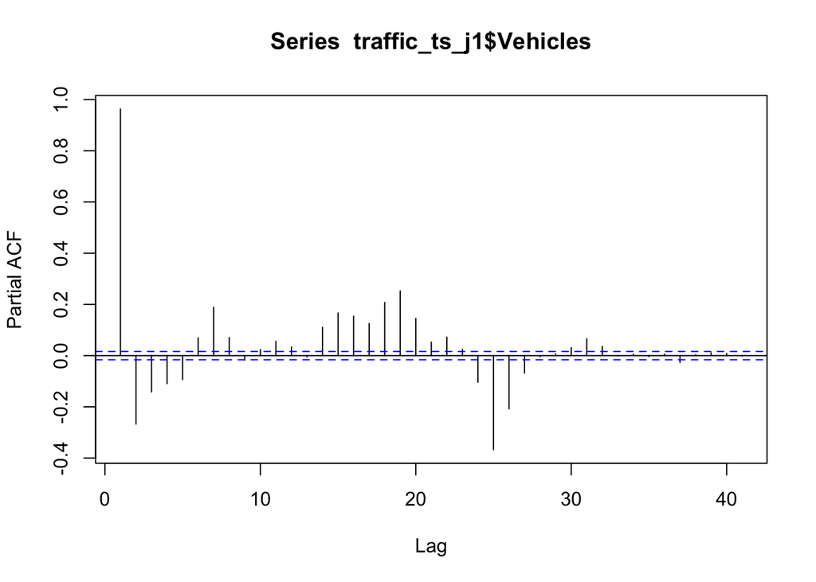

```r
pacf(traffic_ts_j1$Vehicles)
```

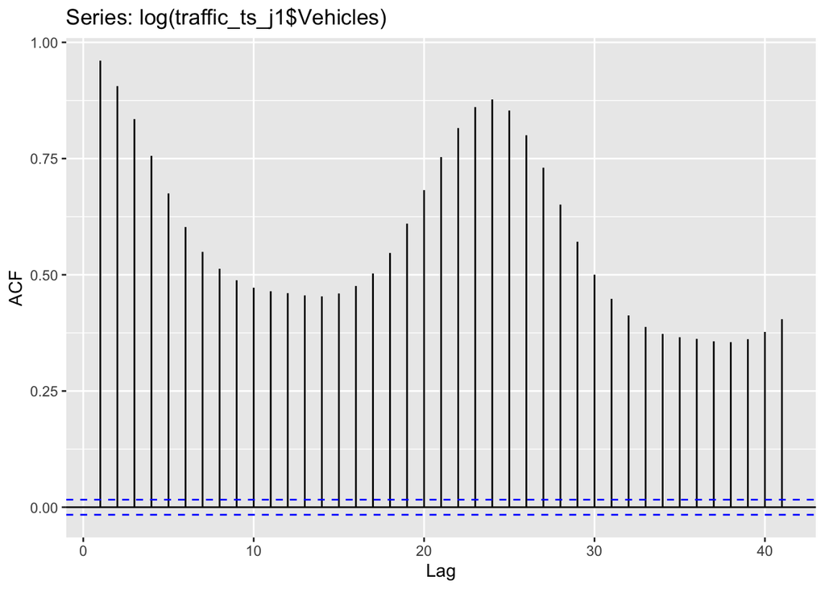

```r
ggAcf(log(traffic_ts_j1$Vehicles))
```

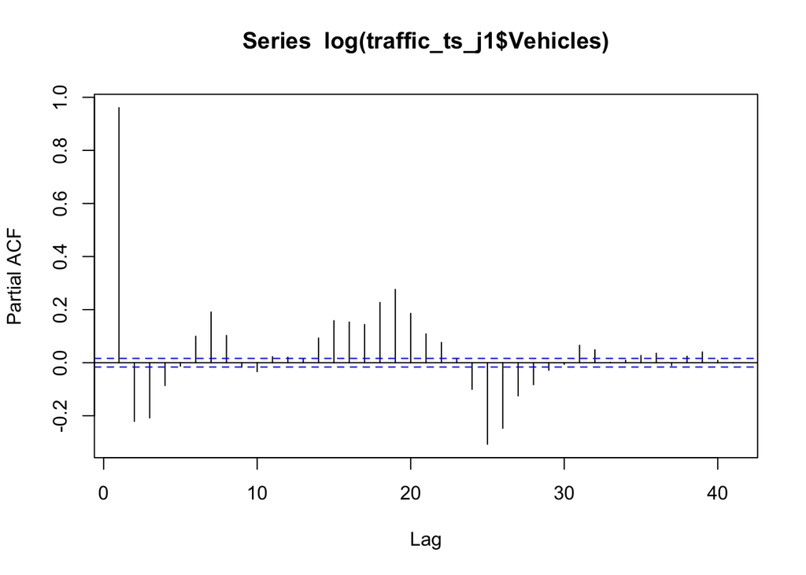

```r
pacf(log(traffic_ts_j1$Vehicles))
```

The ACF plot shows significant autocorrelations at multiple lags, which indicates a persistent, long-term correlation structure. This can suggest that the series is not stationary, as stationary time series typically have autocorrelations that diminish quickly.

The PACF plot shows that the partial autocorrelations drop off quickly after a few lags, which might indicate that the series could be autoregressive (AR) with a finite order.

**Perform the Dickey-Fuller test:**

```r
adf_result <- adf.test(log(traffic_ts_j1$Vehicles))
print(adf_result)
```

```
##
##  Augmented Dickey-Fuller Test
##
## data:  log(traffic_ts_j1$Vehicles)
## Dickey-Fuller = -11.759, Lag order = 24, p-value = 0.01
## alternative hypothesis: stationary
```

The Dickey-Fuller test was the first statistical test developed to test the null hypothesis that a unit root is present in an autoregressive model of a given time series, and that the process is thus not stationary.

P-value = 0.01: Strong evidence against the null hypothesis. Decision: Reject the null hypothesis. Conclusion: The time series is likely stationary.

**Perform the KPSS Test:**

```r
kpss_result <- kpss.test(log(traffic_ts_j1$Vehicles))
print(kpss_result)
```

```
##
##  KPSS Test for Level Stationarity
##
## data:  log(traffic_ts_j1$Vehicles)
## KPSS Level = 72.911, Truncation lag parameter = 13, p-value = 0.01
```

P-value = 0.01: Strong evidence against the null hypothesis. Decision: Reject the null hypothesis. Conclusion: The time series is likely non-stationary, suggesting the presence of a unit root.

ADF Test: Suggests the series is stationary. KPSS Test: Suggests the series is non-stationary.

**Difference the data to see if we can resolve the stationary issue:**

```r
# Differencing the series
traffic_j1_diff <- diff(log(traffic_j1$Vehicles))

# Perform the ADF test on differenced series
adf_result_diff <- adf.test(traffic_j1_diff)
print(adf_result_diff)
```

```
##
##  Augmented Dickey-Fuller Test
##
## data:  traffic_j1_diff
## Dickey-Fuller = -24.995, Lag order = 24, p-value = 0.01
## alternative hypothesis: stationary
```

```r
# Perform the KPSS test on differenced series
kpss_result_diff <- kpss.test(traffic_j1_diff)
print(kpss_result_diff)
```

```
##
##  KPSS Test for Level Stationarity
##
## data:  traffic_j1_diff
## KPSS Level = 0.00051497, Truncation lag parameter = 13, p-value = 0.1
```

Given the p-value of 0.1, which is greater than the common significance level of 0.05, we fail to reject the null hypothesis. This suggests that the series traffic_j1_diff is likely level stationary. There is not enough evidence to conclude that the series has a unit root, indicating that differencing the data might have successfully achieved stationarity.

**Detrend the data to see if we can resolve the stationary issue:**

```r
# Detrending the series
traffic_j1_detrended <- residuals(lm(log(traffic_j1$Vehicles) ~ time(log(traffic_j1$Vehicles))))

# Perform the ADF test on detrended series
adf_result_detrended <- adf.test(traffic_j1_detrended)
print(adf_result_detrended)
```

```
##
##  Augmented Dickey-Fuller Test
##
## data:  traffic_j1_detrended
## Dickey-Fuller = -11.759, Lag order = 24, p-value = 0.01
## alternative hypothesis: stationary
```

```r
# Perform the KPSS test on detrended series
kpss_result_detrended <- kpss.test(traffic_j1_detrended)
print(kpss_result_detrended)
```

```
##
##  KPSS Test for Level Stationarity
##
## data:  traffic_j1_detrended
## KPSS Level = 1.1628, Truncation lag parameter = 13, p-value = 0.01
```

P-value = 0.01: Strong evidence against the null hypothesis. Decision: Reject the null hypothesis. Conclusion: The time series is likely non-stationary, suggesting the presence of a unit root.

This suggests that we should difference the data to make it stationary.

**Check for outliers**

```r
traffic_ts_j1 <- traffic_ts_j1 %>%
  mutate(Z_score = (Vehicles - mean(Vehicles, na.rm = TRUE)) / sd(Vehicles, na.rm = TRUE))

# Identify outliers
outliers <- traffic_ts_j1 %>%
  filter(abs(Z_score) > 3)

count(outliers)
```

```
## # A tibble: 1 × 1
##       n
##   <int>
## 1    64
```

```r
traffic_ts_j1 <- traffic_ts_j1 %>%
  mutate(Z_score = (log(Vehicles) - mean(log(Vehicles), na.rm = TRUE)) / sd(log(Vehicles), na.rm = TRUE))

# Identify outliers
outliers <- traffic_ts_j1 %>%
  filter(abs(Z_score) > 3)

count(outliers)
```

```
## # A tibble: 1 × 1
##       n
##   <int>
## 1    13
```

```r
library(tsoutliers)
# Detect outliers using the tsoutliers package
outliers <- tsoutliers(traffic_ts_j1$Vehicles)

print(outliers)
```

```
## $index
## [1] 11300
##
## $replacements
## [1] 125.5
```

**Data Distribution:**

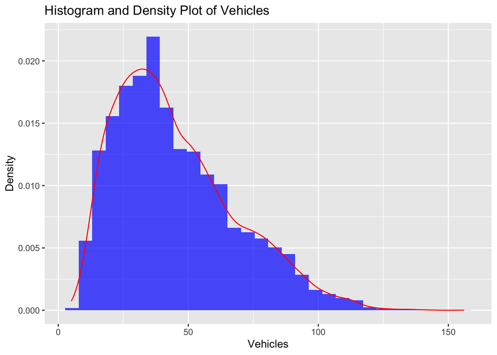

```r
# Plot histogram and density plot of original data
ggplot(traffic_ts_j1, aes(x = Vehicles)) +
  geom_histogram(aes(y = ..density..), bins = 30, fill = "blue", alpha = 0.7) +
  geom_density(color = "red") +
  labs(title = "Histogram and Density Plot of Vehicles", x = "Vehicles", y = "Density")
```

**Summary Statistics**

```r
# Summary statistics of original data
summary(traffic_ts_j1$Vehicles)
```

```
##    Min. 1st Qu.  Median    Mean 3rd Qu.    Max.
##    5.00   27.00   40.00   45.05   59.00  156.00
```

## Junction 2

**Plot the data:**

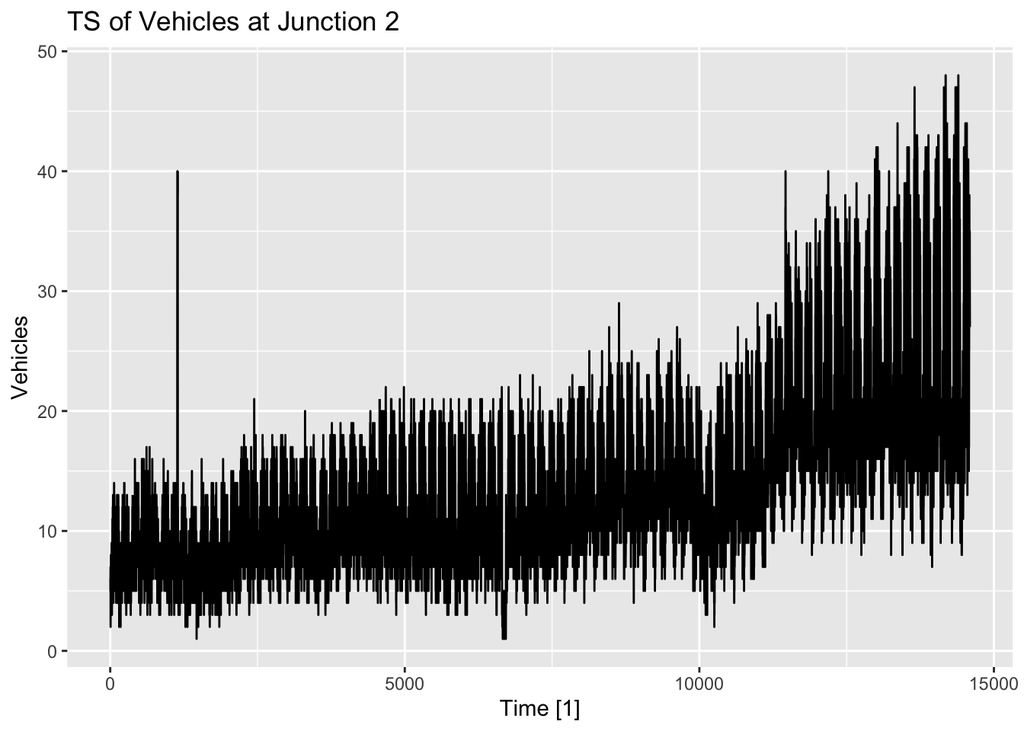

```r
traffic_ts_j2 %>%
  autoplot(Vehicles) +
  labs(title = "TS of Vehicles at Junction 2")
```

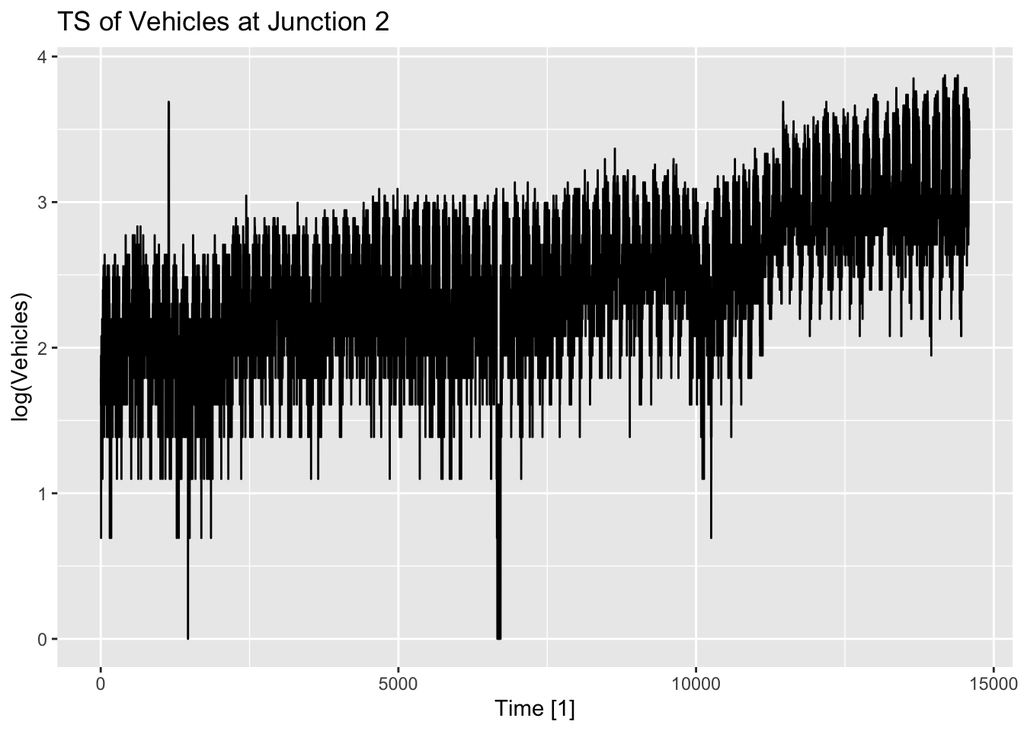

```r
traffic_ts_j2 %>%
  autoplot(log(Vehicles)) +
  labs(title = "TS of Vehicles at Junction 2")
```

Logging the data helps with the heteroskdasticity

**Looking at Autocorrelation Function**

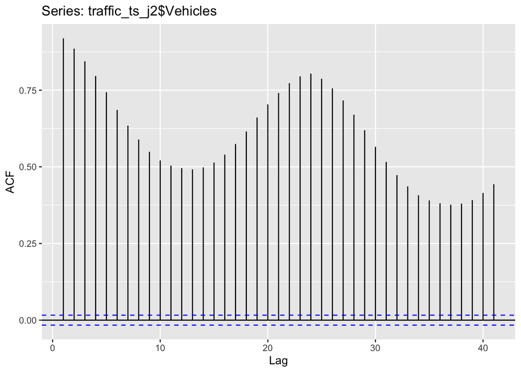

```r
ggAcf(traffic_ts_j2$Vehicles)
```

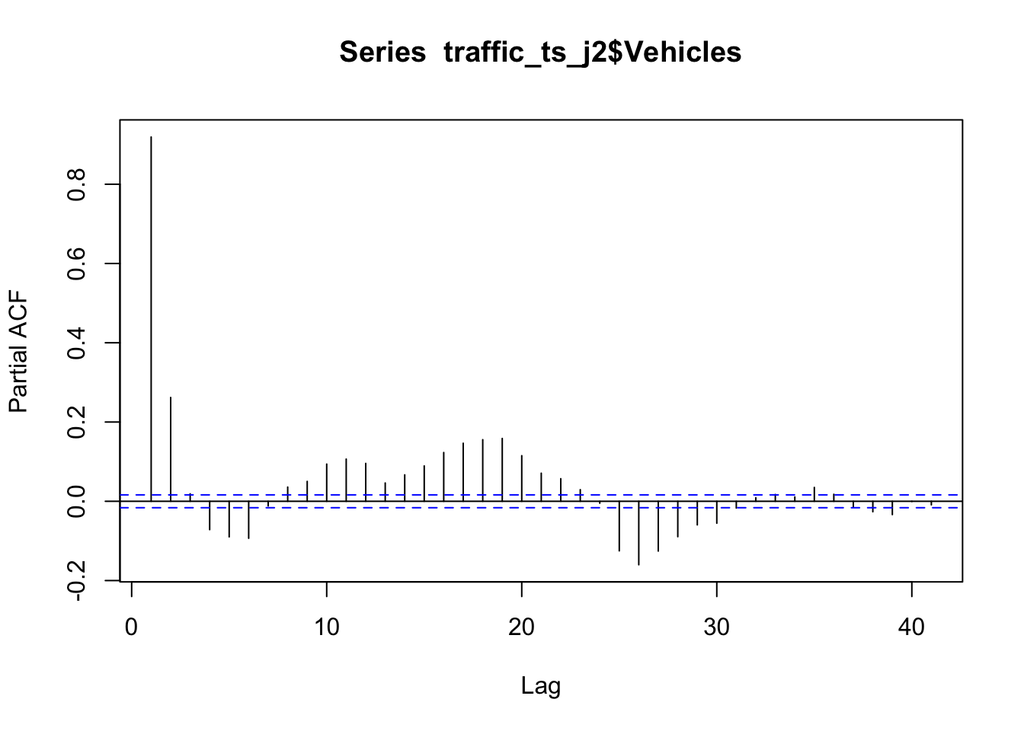

```r
pacf(traffic_ts_j2$Vehicles)
```

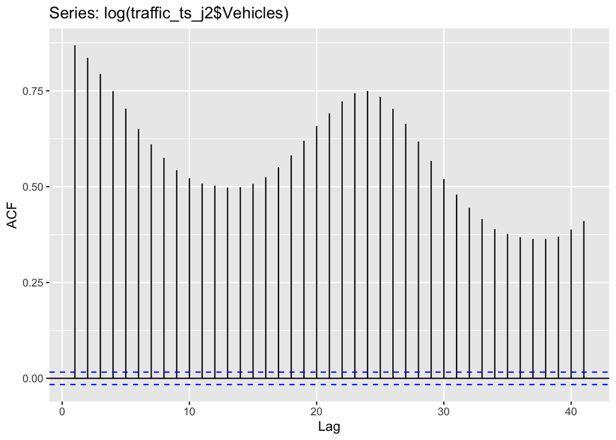

```r
ggAcf(log(traffic_ts_j2$Vehicles))
```

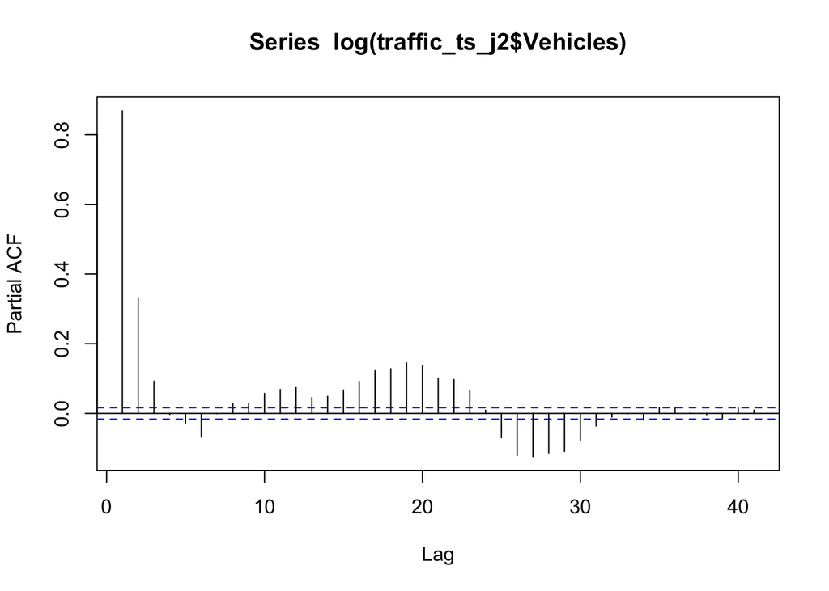

```r
pacf(log(traffic_ts_j2$Vehicles))
```

The ACF plot suggests that there is a clear seasonality or cyclic pattern in the traffic data. The periodic peaks could indicate regular traffic patterns, such as daily or weekly cycles.

The ACF plot shows a significant autocorrelation at lag 1, which slowly decays over time, indicating that each data point is correlated with its previous points.

The PACF plot shows a significant spike at lag 1 and then quickly drops off, with minor spikes at higher lags. This suggests that the immediate past value has a strong influence on the current value, but after accounting for the lag 1 effect, the influence of further lags diminishes

**Perform the Dickey-Fuller test:**

```r
adf_result <- adf.test(log(traffic_ts_j2$Vehicles))
print(adf_result)
```

```
##
##  Augmented Dickey-Fuller Test
##
## data:  log(traffic_ts_j2$Vehicles)
## Dickey-Fuller = -8.7307, Lag order = 24, p-value = 0.01
## alternative hypothesis: stationary
```

The Dickey-Fuller test was the first statistical test developed to test the null hypothesis that a unit root is present in an autoregressive model of a given time series, and that the process is thus not stationary.

P-value = 0.01: Strong evidence against the null hypothesis. Decision: Reject the null hypothesis. Conclusion: The time series is likely stationary.

**Perform the KPSS Test:**

```r
kpss_result <- kpss.test(log(traffic_ts_j2$Vehicles))
print(kpss_result)
```

```
##
##  KPSS Test for Level Stationarity
##
## data:  log(traffic_ts_j2$Vehicles)
## KPSS Level = 60.147, Truncation lag parameter = 13, p-value = 0.01
```

P-value = 0.01: Strong evidence against the null hypothesis. Decision: Reject the null hypothesis. Conclusion: The time series is likely non-stationary, suggesting the presence of a unit root.

ADF Test: Suggests the series is stationary. KPSS Test: Suggests the series is non-stationary.

**Difference the data to see if we can resolve the stationary issue:**

```r
# Differencing the series
traffic_j2_diff <- diff(log(traffic_j2$Vehicles))

# Perform the ADF test on differenced series
adf_result_diff <- adf.test(traffic_j2_diff)
print(adf_result_diff)
```

```
##
##  Augmented Dickey-Fuller Test
##
## data:  traffic_j2_diff
## Dickey-Fuller = -37.578, Lag order = 24, p-value = 0.01
## alternative hypothesis: stationary
```

```r
# Perform the KPSS test on differenced series
kpss_result_diff <- kpss.test(traffic_j2_diff)
print(kpss_result_diff)
```

```
##
##  KPSS Test for Level Stationarity
##
## data:  traffic_j2_diff
## KPSS Level = 0.00059103, Truncation lag parameter = 13, p-value = 0.1
```

Given the p-value of 0.1, which is greater than the common significance level of 0.05, we fail to reject the null hypothesis. This suggests that the series traffic_j2_diff is likely level stationary. There is not enough evidence to conclude that the series has a unit root, indicating that differencing the data might have successfully achieved stationarity.

**Detrend the data to see if we can resolve the stationary issue:**

```r
# Detrending the series
traffic_j2_detrended <- residuals(lm(log(traffic_j2$Vehicles) ~ time(log(traffic_j2$Vehicles))))

# Perform the ADF test on detrended series
adf_result_detrended <- adf.test(traffic_j2_detrended)
print(adf_result_detrended)
```

```
##
##  Augmented Dickey-Fuller Test
##
## data:  traffic_j2_detrended
## Dickey-Fuller = -8.7307, Lag order = 24, p-value = 0.01
## alternative hypothesis: stationary
```

```r
# Perform the KPSS test on detrended series
kpss_result_detrended <- kpss.test(traffic_j2_detrended)
print(kpss_result_detrended)
```

```
##
##  KPSS Test for Level Stationarity
##
## data:  traffic_j2_detrended
## KPSS Level = 2.0072, Truncation lag parameter = 13, p-value = 0.01
```

P-value = 0.01: Strong evidence against the null hypothesis. Decision: Reject the null hypothesis. Conclusion: The time series is likely non-stationary, suggesting the presence of a unit root.

This suggests that we should difference the data to make it stationary.

**Check for outliers**

```r
traffic_ts_j2 <- traffic_ts_j2 %>%
  mutate(Z_score = (Vehicles - mean(Vehicles, na.rm = TRUE)) / sd(Vehicles, na.rm = TRUE))

# Identify outliers
outliers <- traffic_ts_j2 %>%
  filter(abs(Z_score) > 3)

count(outliers)
```

```
## # A tibble: 1 × 1
##       n
##   <int>
## 1   236
```

```r
traffic_ts_j2 <- traffic_ts_j2 %>%
  mutate(Z_score = (log(Vehicles) - mean(log(Vehicles), na.rm = TRUE)) / sd(log(Vehicles), na.rm = TRUE))

# Identify outliers
outliers <- traffic_ts_j2 %>%
  filter(abs(Z_score) > 3)

count(outliers)
```

```
## # A tibble: 1 × 1
##       n
##   <int>
## 1    37
```

```r
library(tsoutliers)

# Detect outliers using the tsoutliers package
outliers <- tsoutliers(traffic_ts_j2$Vehicles)

print(outliers)
```

```
## $index
## [1] 1140 1141 1142 1143 1144 1145
##
## $replacements
## [1] 28.85714 27.71429 26.57143 25.42857 24.28571 23.14286
```

**Data Distribution:**

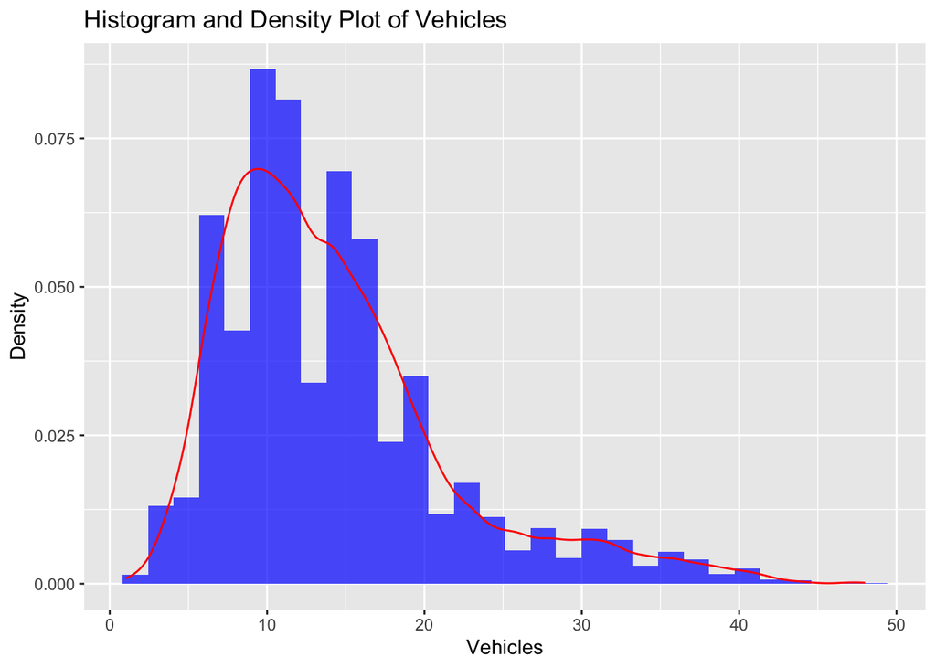

```r
# Plot histogram and density plot of original data
ggplot(traffic_ts_j2, aes(x = Vehicles)) +
  geom_histogram(aes(y = ..density..), bins = 30, fill = "blue", alpha = 0.7) +
  geom_density(color = "red") +
  labs(title = "Histogram and Density Plot of Vehicles", x = "Vehicles", y = "Density")
```

**Summary Statistics**

```r
# Summary statistics of original data
summary(traffic_ts_j2$Vehicles)
```

```
##    Min. 1st Qu.  Median    Mean 3rd Qu.    Max.
##    1.00    9.00   13.00   14.25   17.00   48.00
```

## Junction 3

**Plot the data:**

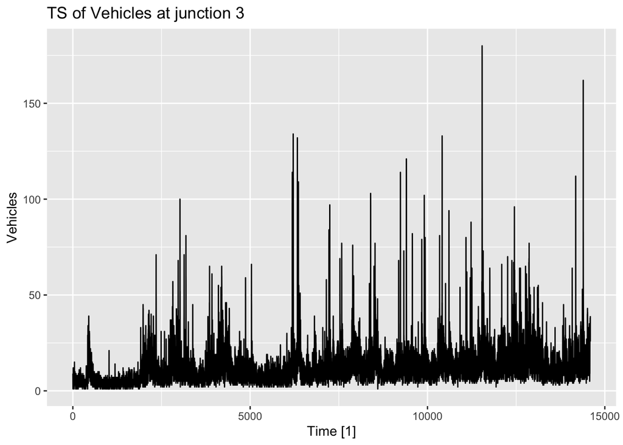

```r
traffic_ts_j3 %>%
  autoplot(Vehicles) +
  labs(title = "TS of Vehicles at junction 3")
```

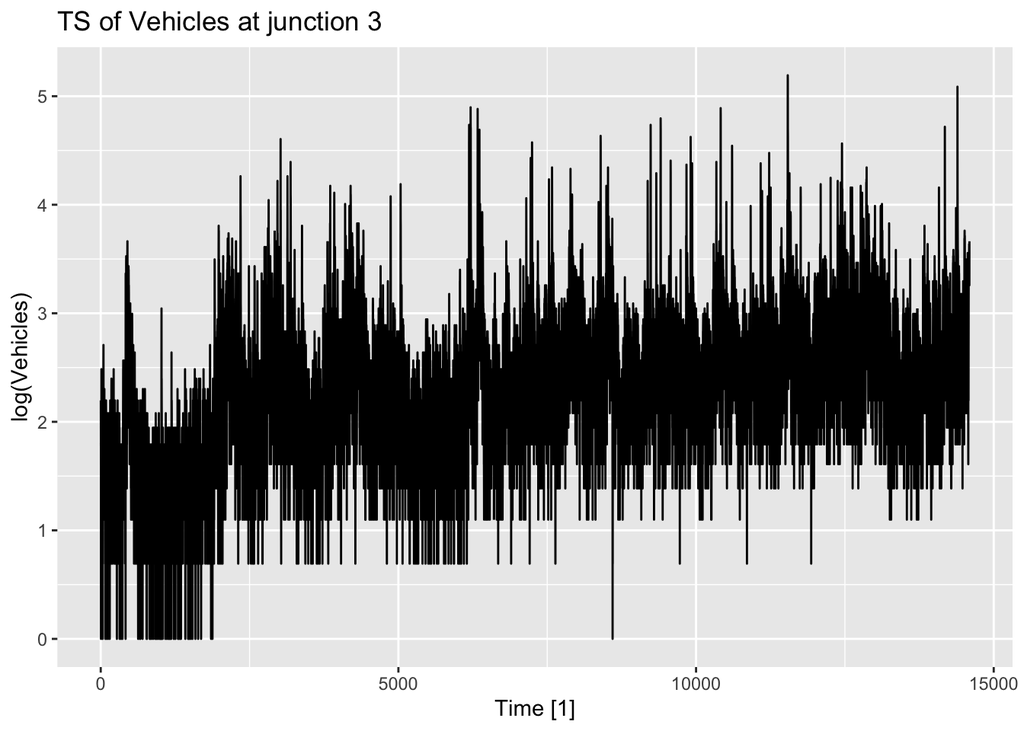

```r
traffic_ts_j3 %>%
  autoplot(log(Vehicles)) +
  labs(title = "TS of Vehicles at junction 3")
```

Logging the data helps with the heteroskdasticity

**Looking at Autocorrelation Function**

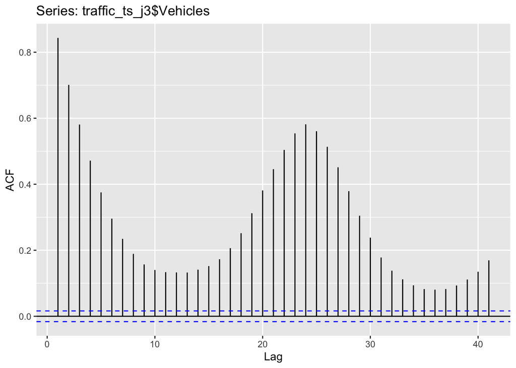

```r
ggAcf(traffic_ts_j3$Vehicles)
```

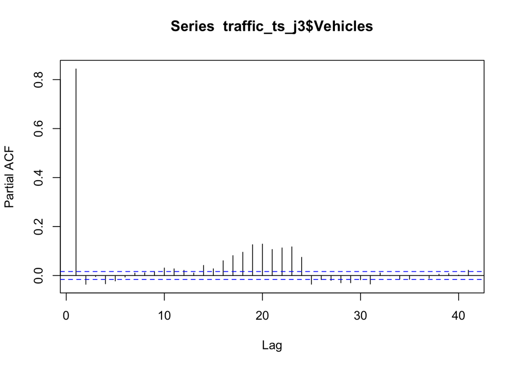

```r
pacf(traffic_ts_j3$Vehicles)
```

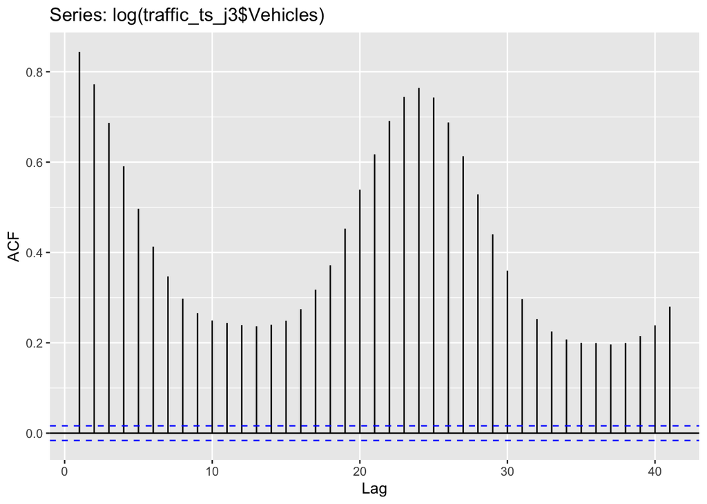

```r
ggAcf(log(traffic_ts_j3$Vehicles))
```

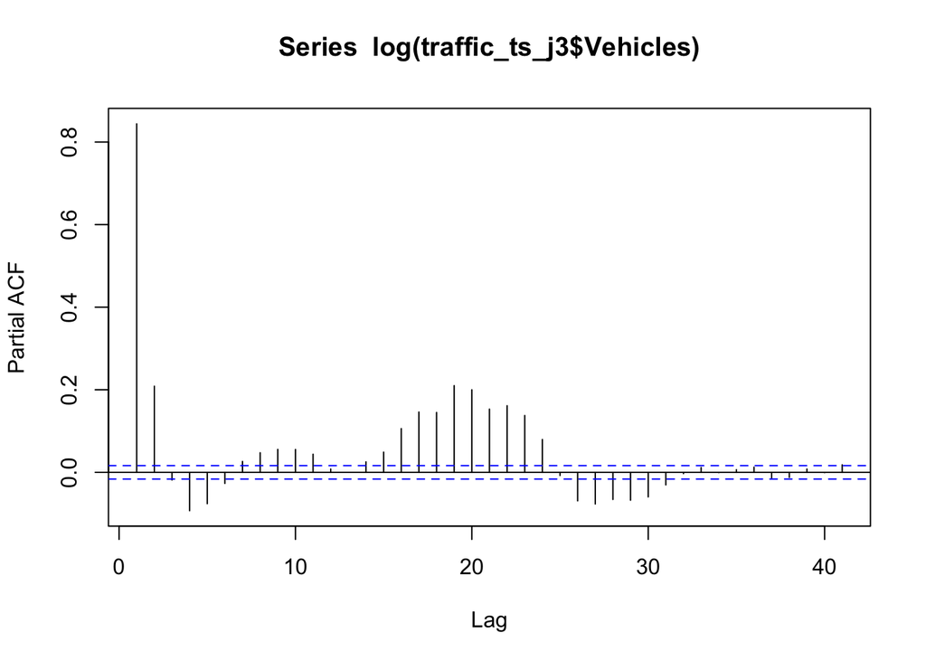

```r
pacf(log(traffic_ts_j3$Vehicles))
```

The ACF plot shows significant autocorrelations at multiple lags, which indicates a persistent, long-term correlation structure. This can suggest that the series is not stationary, as stationary time series typically have autocorrelations that diminish quickly.

The PACF plot shows that the partial autocorrelations drop off quickly after a few lags, which might indicate that the series could be autoregressive (AR) with a finite order.

**Perform the Dickey-Fuller test:**

```r
adf_result <- adf.test(log(traffic_ts_j3$Vehicles))
print(adf_result)
```

```
##
##  Augmented Dickey-Fuller Test
##
## data:  log(traffic_ts_j3$Vehicles)
## Dickey-Fuller = -5.9562, Lag order = 24, p-value = 0.01
## alternative hypothesis: stationary
```

The Dickey-Fuller test was the first statistical test developed to test the null hypothesis that a unit root is present in an autoregressive model of a given time series, and that the process is thus not stationary.

P-value = 0.01: Strong evidence against the null hypothesis. Decision: Reject the null hypothesis. Conclusion: The time series is likely stationary.

**Perform the KPSS Test:**

```r
kpss_result <- kpss.test(log(traffic_ts_j3$Vehicles))
print(kpss_result)
```

```
##
##  KPSS Test for Level Stationarity
##
## data:  log(traffic_ts_j3$Vehicles)
## KPSS Level = 34.944, Truncation lag parameter = 13, p-value = 0.01
```

P-value = 0.01: Strong evidence against the null hypothesis. Decision: Reject the null hypothesis. Conclusion: The time series is likely non-stationary, suggesting the presence of a unit root.

ADF Test: Suggests the series is stationary. KPSS Test: Suggests the series is non-stationary.

**Difference the data to see if we can resolve the stationary issue:**

```r
# Differencing the series
traffic_j3_diff <- diff(log(traffic_j3$Vehicles))

# Perform the ADF test on differenced series
adf_result_diff <- adf.test(traffic_j3_diff)
print(adf_result_diff)
```

```
##
##  Augmented Dickey-Fuller Test
##
## data:  traffic_j3_diff
## Dickey-Fuller = -49.199, Lag order = 24, p-value = 0.01
## alternative hypothesis: stationary
```

```r
# Perform the KPSS test on differenced series
kpss_result_diff <- kpss.test(traffic_j3_diff)
print(kpss_result_diff)
```

```
##
##  KPSS Test for Level Stationarity
##
## data:  traffic_j3_diff
## KPSS Level = 0.0009162, Truncation lag parameter = 13, p-value = 0.1
```

Given the p-value of 0.1, which is greater than the common significance level of 0.05, we fail to reject the null hypothesis. This suggests that the series traffic_j3_diff is likely level stationary. There is not enough evidence to conclude that the series has a unit root, indicating that differencing the data might have successfully achieved stationarity.

**Detrend the data to see if we can resolve the stationary issue:**

```r
# Detrending the series
traffic_j3_detrended <- residuals(lm(log(traffic_j3$Vehicles) ~ time(log(traffic_j3$Vehicles))))

# Perform the ADF test on detrended series
adf_result_detrended <- adf.test(traffic_j3_detrended)
print(adf_result_detrended)
```

```
##
##  Augmented Dickey-Fuller Test
##
## data:  traffic_j3_detrended
## Dickey-Fuller = -5.9562, Lag order = 24, p-value = 0.01
## alternative hypothesis: stationary
```

```r
# Perform the KPSS test on detrended series
kpss_result_detrended <- kpss.test(traffic_j3_detrended)
print(kpss_result_detrended)
```

```
##
##  KPSS Test for Level Stationarity
##
## data:  traffic_j3_detrended
## KPSS Level = 2.287, Truncation lag parameter = 13, p-value = 0.01
```

P-value = 0.01: Strong evidence against the null hypothesis. Decision: Reject the null hypothesis. Conclusion: The time series is likely non-stationary, suggesting the presence of a unit root.

This suggests that we should difference the data to make it stationary.

**Check for outliers**

```r
traffic_ts_j3 <- traffic_ts_j3 %>%
  mutate(Z_score = (Vehicles - mean(Vehicles, na.rm = TRUE)) / sd(Vehicles, na.rm = TRUE))

# Identify outliers
outliers <- traffic_ts_j3 %>%
  filter(abs(Z_score) > 3)

count(outliers)
```

```
## # A tibble: 1 × 1
##       n
##   <int>
## 1   202
```

```r
traffic_ts_j3 <- traffic_ts_j3 %>%
  mutate(Z_score = (log(Vehicles) - mean(log(Vehicles), na.rm = TRUE)) / sd(log(Vehicles), na.rm = TRUE))

# Identify outliers
outliers <- traffic_ts_j3 %>%
  filter(abs(Z_score) > 3)

count(outliers)
```

```
## # A tibble: 1 × 1
##       n
##   <int>
## 1   110
```

```r
library(tsoutliers)

# Detect outliers using the tsoutliers package
outliers <- tsoutliers(traffic_ts_j3$Vehicles)

print(outliers)
```

```
## $index
##   [1]   428   447   448   449  1980  1981  1983  2133  2147  2148  2208  2347
##  [13]  2348  2349  2350  2809  2820  2821  2922  2968  2969  2970  2972  3020
##  [25]  3021  3022  3023  3136  3137  3138  3189  3190  3191  3192  3381  3852
##  [37]  3855  3922  3923  3924  4105  4177  4188  4189  4196  4197  4198  4199
##  [49]  4200  4201  4308  4321  4332  4412  4869  4870  4871  5036  5037  5038
##  [61]  5039  6187  6188  6189  6190  6191  6212  6213  6214  6215  6216  6331
##  [73]  6332  6333  6334  6335  6361  6362  6372  6373  6374  6375  6376  6377
##  [85]  6378  6379  6381  6382  6383  6384  6385  6398  6405  6406  6408  6409
##  [97]  7148  7149  7220  7221  7222  7245  7246  7247  7529  7530  7581  7582
## [109]  7873  7891  7892  7893  7894  7895  7917  7918  8362  8363  8396  8397
## [121]  8398  8493  8494  8521  8532  8533  8593  9187  9188  9236  9237  9238
## [133]  9239  9332  9333  9404  9405  9406  9407  9572  9573  9574  9839  9840
## [145]  9908  9909  9910  9933  9934  9935 10341 10342 10411 10412 10413 10414
## [157] 10415 10509 10604 10605 10606 10917 10918 11085 11086 11109 11110 11204
```

[output cut: 40 more lines]

**Data Distribution:**

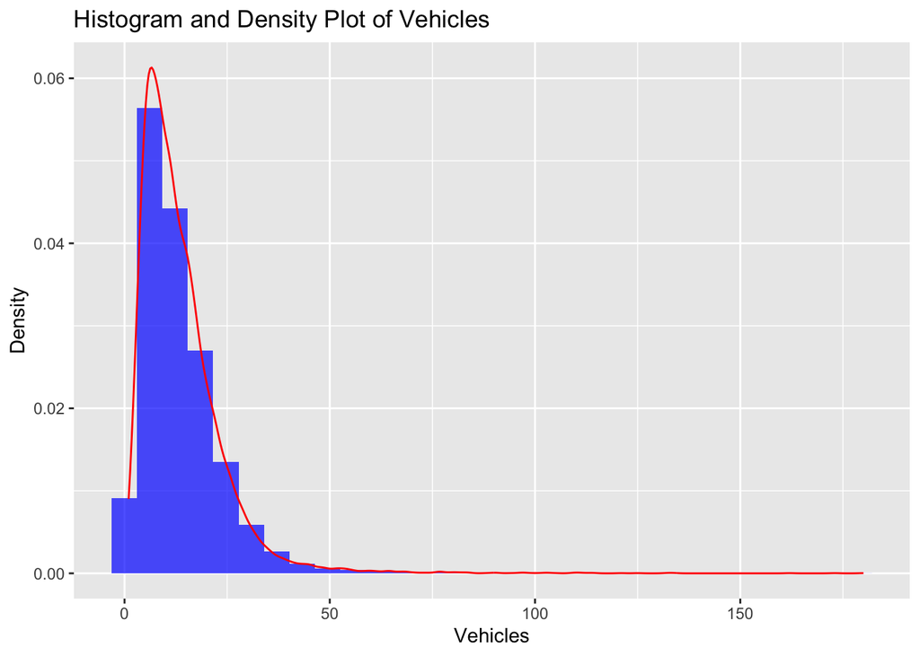

```r
# Plot histogram and density plot of original data
ggplot(traffic_ts_j3, aes(x = Vehicles)) +
  geom_histogram(aes(y = ..density..), bins = 30, fill = "blue", alpha = 0.7) +
  geom_density(color = "red") +
  labs(title = "Histogram and Density Plot of Vehicles", x = "Vehicles", y = "Density")
```

**Summary Statistics**

```r
# Summary statistics of original data
summary(traffic_ts_j3$Vehicles)
```

```
##    Min. 1st Qu.  Median    Mean 3rd Qu.    Max.
##    1.00    7.00   11.00   13.69   18.00  180.00
```

## Junction 4

**Plot data:**

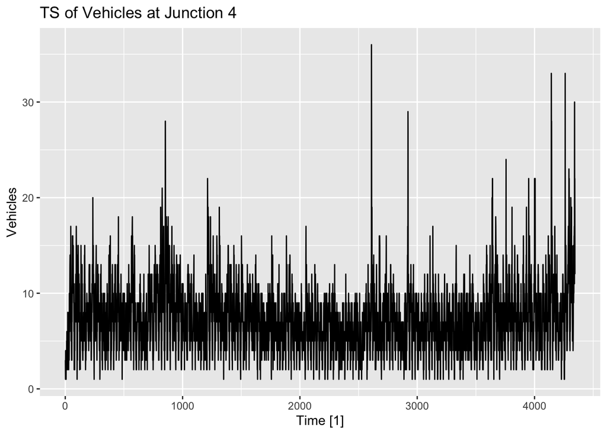

```r
traffic_ts_j4 %>%
  autoplot(Vehicles) +
  labs(title = "TS of Vehicles at Junction 4")
```

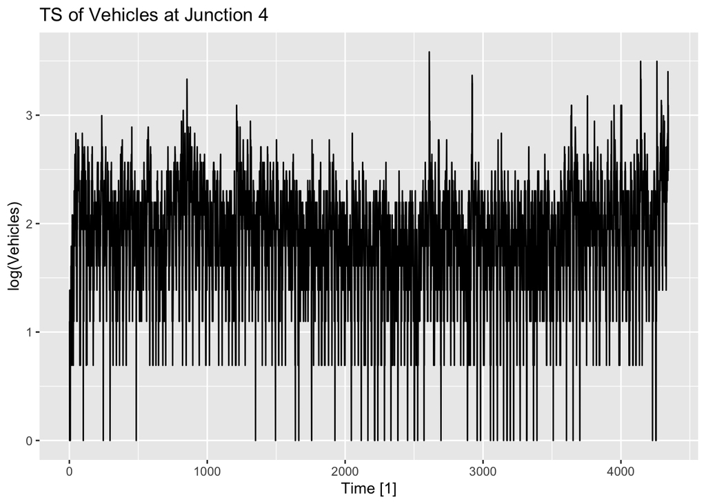

```r
traffic_ts_j4 %>%
  autoplot(log(Vehicles)) +
  labs(title = "TS of Vehicles at Junction 4")
```

Logging the data helps with the heteroskdasticity

**Looking at Autocorrelation Function**

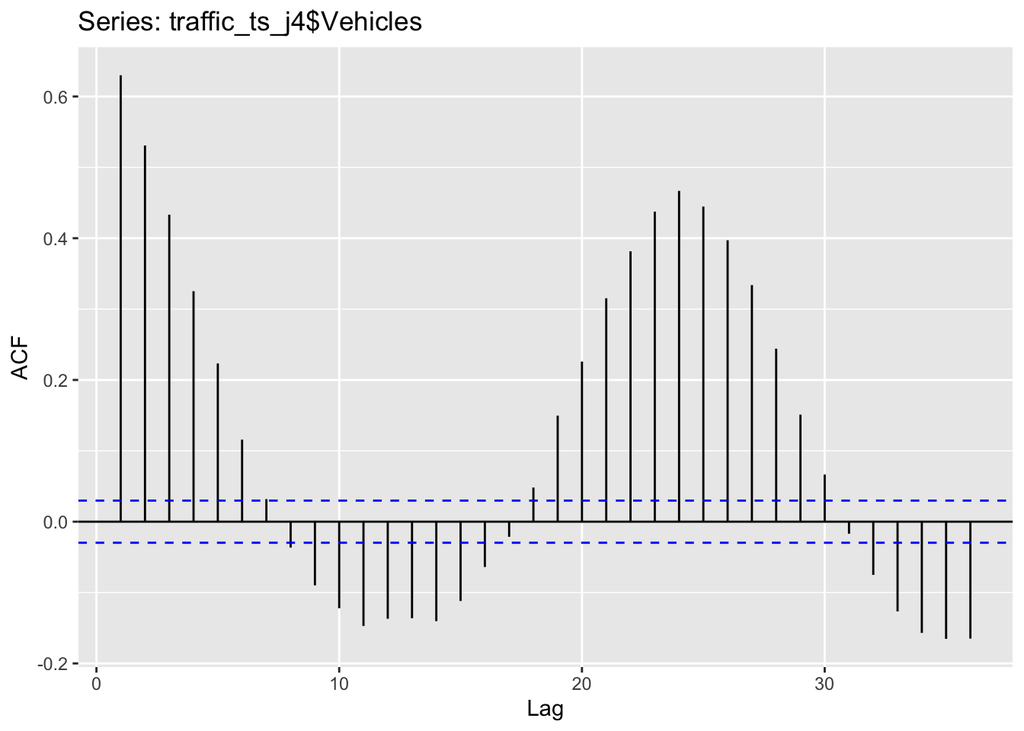

```r
ggAcf(traffic_ts_j4$Vehicles)
```

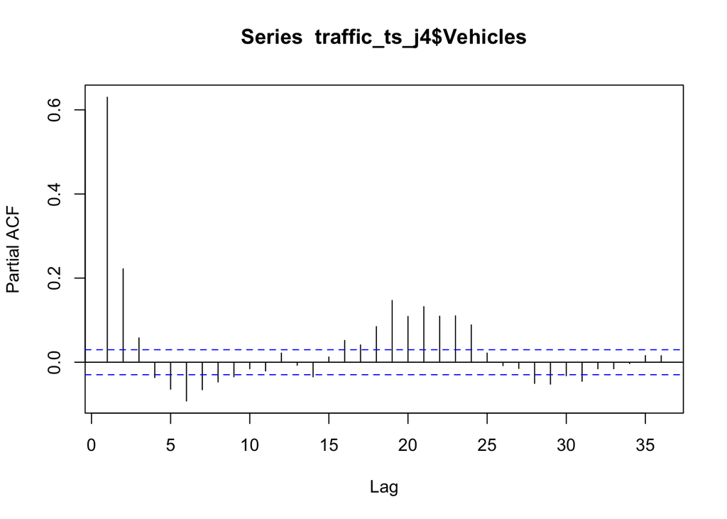

```r
pacf(traffic_ts_j4$Vehicles)
```

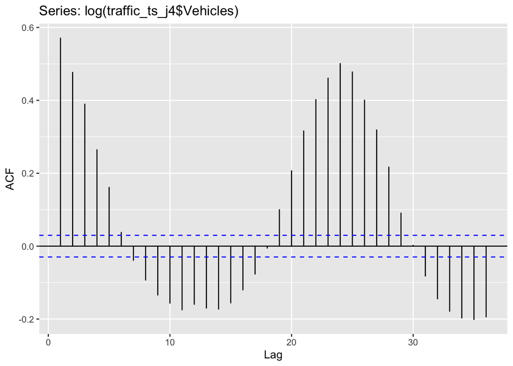

```r
ggAcf(log(traffic_ts_j4$Vehicles))
```

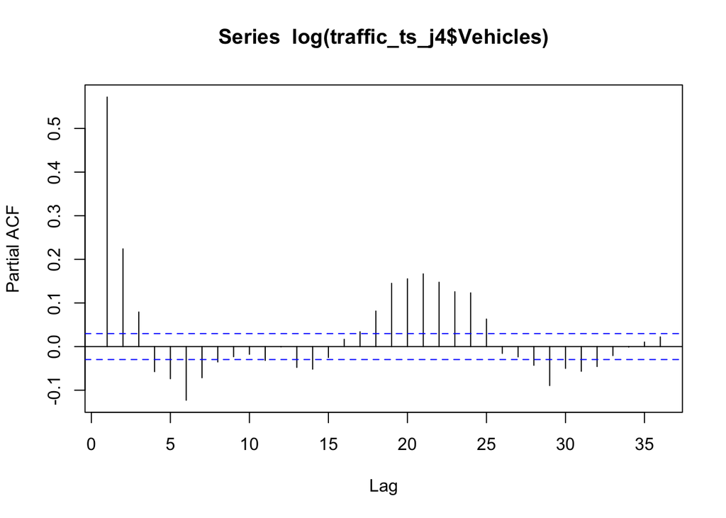

```r
pacf(log(traffic_ts_j4$Vehicles))
```

The ACF plot shows significant autocorrelations at multiple lags, which indicates a persistent, long-term correlation structure. This can suggest that the series is not stationary, as stationary time series typically have autocorrelations that diminish quickly.

The PACF plot shows that the partial autocorrelations drop off quickly after a few lags, which might indicate that the series could be autoregressive (AR) with a finite order.

**Perform the Dickey-Fuller test:**

```r
adf_result <- adf.test(log(traffic_ts_j4$Vehicles))
print(adf_result)
```

```
##
##  Augmented Dickey-Fuller Test
##
## data:  log(traffic_ts_j4$Vehicles)
## Dickey-Fuller = -17.596, Lag order = 16, p-value = 0.01
## alternative hypothesis: stationary
```

The Dickey-Fuller test was the first statistical test developed to test the null hypothesis that a unit root is present in an autoregressive model of a given time series, and that the process is thus not stationary.

P-value = 0.01: Strong evidence against the null hypothesis. Decision: Reject the null hypothesis. Conclusion: The time series is likely stationary.

**Perform the KPSS Test:**

```r
kpss_result <- kpss.test(log(traffic_ts_j4$Vehicles))
print(kpss_result)
```

```
##
##  KPSS Test for Level Stationarity
##
## data:  log(traffic_ts_j4$Vehicles)
## KPSS Level = 1.2366, Truncation lag parameter = 10, p-value = 0.01
```

P-value = 0.01: Strong evidence against the null hypothesis. Decision: Reject the null hypothesis. Conclusion: The time series is likely non-stationary, suggesting the presence of a unit root.

ADF Test: Suggests the series is stationary. KPSS Test: Suggests the series is non-stationary.

**Difference the data to see if we can resolve the stationary issue:**

```r
# Differencing the series
traffic_j4_diff <- diff(log(traffic_j4$Vehicles))

# Perform the ADF test on differenced series
adf_result_diff <- adf.test(traffic_j4_diff)
print(adf_result_diff)
```

```
##
##  Augmented Dickey-Fuller Test
##
## data:  traffic_j4_diff
## Dickey-Fuller = -29.561, Lag order = 16, p-value = 0.01
## alternative hypothesis: stationary
```

```r
# Perform the KPSS test on differenced series
kpss_result_diff <- kpss.test(traffic_j4_diff)
print(kpss_result_diff)
```

```
##
##  KPSS Test for Level Stationarity
##
## data:  traffic_j4_diff
## KPSS Level = 0.0017787, Truncation lag parameter = 10, p-value = 0.1
```

Given the p-value of 0.1, which is greater than the common significance level of 0.05, we fail to reject the null hypothesis. This suggests that the series traffic_j4_diff is likely level stationary. There is not enough evidence to conclude that the series has a unit root, indicating that differencing the data might have successfully achieved stationarity.

**Detrend the data to see if we can resolve the stationary issue:**

```r
# Detrending the series
traffic_j4_detrended <- residuals(lm(log(traffic_j4$Vehicles) ~ time(log(traffic_j4$Vehicles))))

# Perform the ADF test on detrended series
adf_result_detrended <- adf.test(traffic_j4_detrended)
print(adf_result_detrended)
```

```
##
##  Augmented Dickey-Fuller Test
##
## data:  traffic_j4_detrended
## Dickey-Fuller = -17.596, Lag order = 16, p-value = 0.01
## alternative hypothesis: stationary
```

```r
# Perform the KPSS test on detrended series
kpss_result_detrended <- kpss.test(traffic_j4_detrended)
print(kpss_result_detrended)
```

```
##
##  KPSS Test for Level Stationarity
##
## data:  traffic_j4_detrended
## KPSS Level = 1.1035, Truncation lag parameter = 10, p-value = 0.01
```

P-value = 0.01: Strong evidence against the null hypothesis. Decision: Reject the null hypothesis. Conclusion: The time series is likely non-stationary, suggesting the presence of a unit root.

This suggests that we should difference the data to make it stationary.

**Check for outliers**

```r
traffic_ts_j4 <- traffic_ts_j4 %>%
  mutate(Z_score = (Vehicles - mean(Vehicles, na.rm = TRUE)) / sd(Vehicles, na.rm = TRUE))

# Identify outliers
outliers <- traffic_ts_j4 %>%
  filter(abs(Z_score) > 3)

count(outliers)
```

```
## # A tibble: 1 × 1
##       n
##   <int>
## 1    48
```

```r
traffic_ts_j4 <- traffic_ts_j4 %>%
  mutate(Z_score = (log(Vehicles) - mean(log(Vehicles), na.rm = TRUE)) / sd(log(Vehicles), na.rm = TRUE))

# Identify outliers
outliers <- traffic_ts_j4 %>%
  filter(abs(Z_score) > 3)

count(outliers)
```

```
## # A tibble: 1 × 1
##       n
##   <int>
## 1    59
```

```r
library(tsoutliers)

# Detect outliers using the tsoutliers package
outliers <- tsoutliers(traffic_ts_j4$Vehicles)

print(outliers)
```

```
## $index
##  [1]  853 2610 2611 2921 2922 3641 3642 3757 4143 4144 4145 4261 4341
##
## $replacements
##  [1] 18.00000 10.33333 11.66667 12.33333 11.66667 12.00000 11.00000 11.50000
##  [9] 13.25000 15.50000 17.75000 15.00000 13.50000
```

**Data Distribution:**

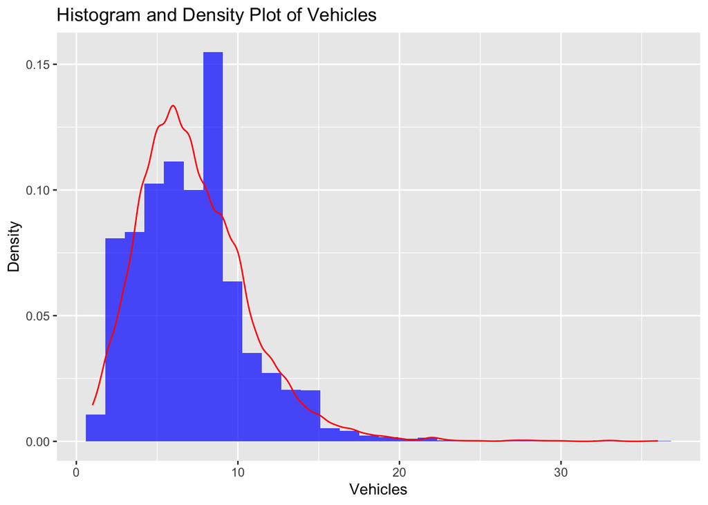

```r
# Plot histogram and density plot of original data
ggplot(traffic_ts_j4, aes(x = Vehicles)) +
  geom_histogram(aes(y = ..density..), bins = 30, fill = "blue", alpha = 0.7) +
  geom_density(color = "red") +
  labs(title = "Histogram and Density Plot of Vehicles", x = "Vehicles", y = "Density")
```

**Summary Statistics**

```r
# Summary statistics of original data
summary(traffic_ts_j4$Vehicles)
```

```
##    Min. 1st Qu.  Median    Mean 3rd Qu.    Max.
##   1.000   5.000   7.000   7.252   9.000  36.000
```